# Exploring China’s Belt and Road Initiative Across Different Regions

## Visualization #3 - The Middle East

```r
Middle_East <- BRI %>%
  select(year, recipient_region, usd_current) %>%
  filter(recipient_region == "Middle East") %>%
  arrange(year) %>%
  select(year, usd_current)

The_MidEast_Avg <- Middle_East %>%
  group_by(year) %>%
  summarize(usd_current = mean(usd_current, na.rm =TRUE)) %>%
  mutate(usd_current2 = usd_current/1000000)
  round(digits = 2)
```

```
## [1] 2
```

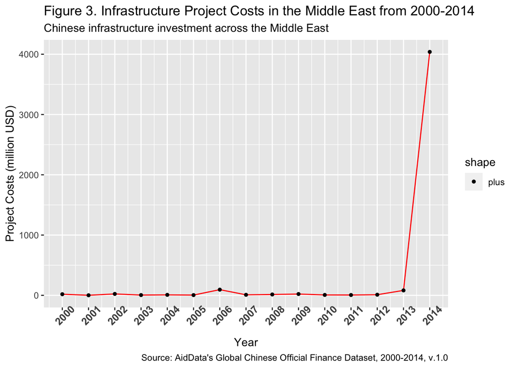

```r
The_MidEast_Avg %>%
  ggplot() +
  geom_line(aes(x = year, y = usd_current2), color = "red") +
  geom_point(aes(x = year, y = usd_current2, shape = "plus")) +
  scale_x_continuous(breaks = seq(2000, 2014, by = 1)) +
  #scale_y_continuous(breaks = seq(700, 77000, by = 7000)) +
  theme(axis.text.x = element_text (face = "bold", size = 10, angle = 45))+
  labs(title = "Figure 3. Infrastructure Project Costs in the Middle East from 2000-2014",
       subtitle = "Chinese infrastructure investment across the Middle East",
       caption = "Source: AidData's Global Chinese Official Finance Dataset, 2000-2014, v.1.0",
       y = "Project Costs (million USD)",
       x ="Year")
```

## Visualization #4 - The Pacific

[figure not shown]

```r
The_Pacific <- BRI %>%
  select(year, recipient_region, usd_current) %>%
  filter(recipient_region == "The Pacific") %>%
  arrange(year) %>%
  select(year, usd_current)

The_Pacific_Avg <- The_Pacific %>%
  group_by(year) %>%
  summarize(usd_current = mean(usd_current, na.rm =TRUE)) %>%
  mutate(usd_current2 = usd_current/100000) %>%
  round(digits = 2)

The_Pacific_Avg %>%
  ggplot() +
  geom_line(aes(x = year, y = usd_current2), color = "blue") +
  geom_point(aes(x = year, y = usd_current2), shape = "triangle") +
  scale_x_continuous(breaks = seq(2000, 2014, by = 1)) +
  #scale_y_continuous(breaks = seq(700, 77000, by = 7000)) +
  theme(axis.text.x = element_text (face = "bold", size = 10, angle = 45))+
  labs(title = "Figure 4. Infrastructure Project Costs in the Pacific from 2000-2014",
       subtitle = "Chinese infrastructure investment across the Pacific",
       caption = "Source: AidData's Global Chinese Official Finance Dataset, 2000-2014, v.1.0",
       y = "Project Costs (million USD)",
       x ="Year")
```

**Interpretation**: Figure 4. shows a lot of variability in infrastructure investment in the Pacific region over 15 years. Unlike Asia and Africa, the Pacific did not see a spike in investment in 2010. Their biggest spikes occurred in 2002, 2007 and 2012; exactly five years apart for each period.

## Visualization #5 - All Regions

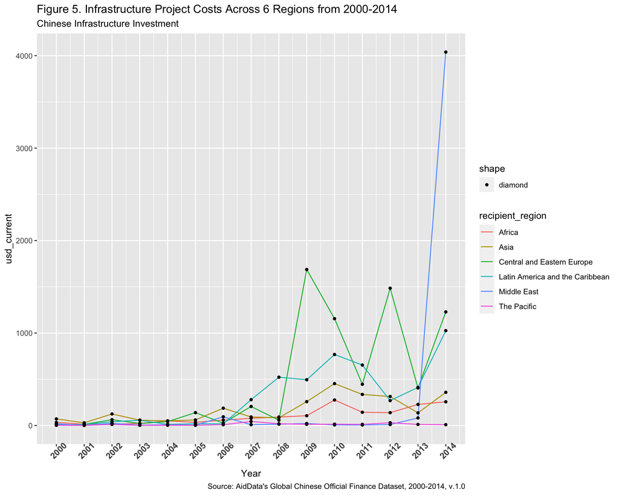

```r
BRI_regions <- BRI %>%
  select(recipient_region, usd_current, year) %>%
  arrange(recipient_region, year)

BRI_regions_avg <- BRI_regions %>%
  group_by(recipient_region, year) %>%
  summarize(usd_current = mean(usd_current, na.rm = TRUE)) %>%
  mutate(usd_current = usd_current/1000000)

BRI_regions_avg %>%
  ggplot() +
  geom_line(aes(x = year, y = usd_current, color = recipient_region), linetype = 7) +
  geom_point(aes(x = year, y = usd_current, shape = "diamond"), fill = "black")+
  scale_x_continuous(breaks = seq(2000, 2014, by =1)) +
  scale_y_continuous("usd_current") +
  theme(axis.text.x = element_text (face = "bold", size = 10, angle = 45))+
  labs(title = "Figure 5. Infrastructure Project Costs Across 6 Regions from 2000-2014",
       subtitle = "Chinese Infrastructure Investment",
       caption = "Source: AidData's Global Chinese Official Finance Dataset, 2000-2014, v.1.0",
       y = "Project Costs (million USD)",
       x ="Year")
```

**Interpretation**: Figure 5. shows regional comparisons of infrastructure investment from 2000-2014. All regions except the Pacific have seen increasing activity and project costs over the past 15 years. Central and Eastern Europe saw the biggest spikes in investment in 2009 and 2012 compared to other regions. However in 2014, the Middle East saw the largest investment in costs compared to all regions over the the entire 15 year period.

# Visualization #6 - All Regions

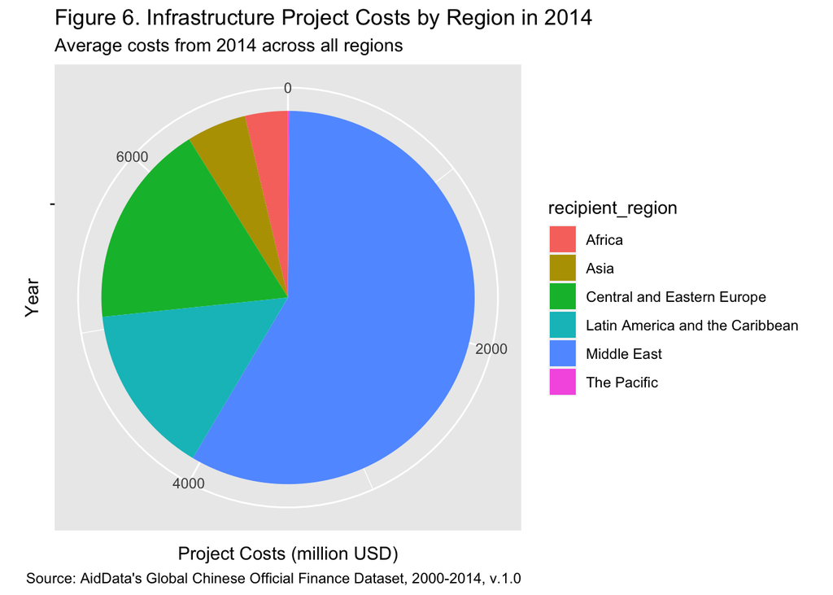

```r
BRI_circle <- BRI %>%
  select(recipient_region, usd_current, year) %>%
  filter(year == "2014") %>%
  group_by(recipient_region, year) %>%
  summarize(usd_current = mean(usd_current, na.rm = TRUE)) %>%
  mutate(usd_current = usd_current/1000000)


BRI_circle %>%
  ggplot(aes(x = "", y = usd_current, fill = recipient_region)) +
  geom_bar(stat = "identity", width = 1) +
  coord_polar("y", start = 0) +
  labs(title = "Figure 6. Infrastructure Project Costs by Region in 2014",
       subtitle = "Average costs from 2014 across all regions",
       caption = "Source: AidData's Global Chinese Official Finance Dataset, 2000-2014, v.1.0",
       y = "Project Costs (million USD)",
       x ="Year")
```

```r
#note: this needs work and I should've converted these amounts to percentages, but ran out of time. I just wanted to see what this looked like.
```